# diabetes

This is a project to discover the insights of diabetes, and how each of the following variables may contribute to whether or not someone as diabetes. We are using a variety of different models, each performing binary classification using a dataset from Kaggle. This Exploratory Data Analysis uses different machine learning models and techniques, namely Logistic Regressiong, Logistic Regression with Preprocessing, and Random Forest.

```python
# Install dependencies as needed:
# pip install kagglehub[pandas-datasets]
import kagglehub
from kagglehub import KaggleDatasetAdapter

# Set the path to the file you'd like to load
file_path = "diabetes.csv"

# Load the latest version
df = kagglehub.load_dataset(
  KaggleDatasetAdapter.PANDAS,
  "uciml/pima-indians-diabetes-database",
  file_path,
  # Provide any additional arguments like
  # sql_query or pandas_kwargs. See the
  # documenation for more information:
  # https://github.com/Kaggle/kagglehub/blob/main/README.md#kaggledatasetadapterpandas
)

print("First 5 records:", df.head())
```

```
First 5 records:    Pregnancies  Glucose  BloodPressure  SkinThickness  Insulin   BMI  \
0            6      148             72             35        0  33.6
1            1       85             66             29        0  26.6
2            8      183             64              0        0  23.3
3            1       89             66             23       94  28.1
4            0      137             40             35      168  43.1

   DiabetesPedigreeFunction  Age  Outcome
0                     0.627   50        1
1                     0.351   31        0
2                     0.672   32        1
3                     0.167   21        0
4                     2.288   33        1
```

```python
features = list(df.columns)[:-1]
label = "Outcome"
features, label
```

```
(['Pregnancies',
  'Glucose',
  'BloodPressure',
  'SkinThickness',
  'Insulin',
  'BMI',
  'DiabetesPedigreeFunction',
  'Age'],
 'Outcome')
```

```python
X,y = df[features].values, df[label].values

for n in range(0, 4):
    print(f"Patient {n}\n Features: {X[n]}\n Outcome:{y[n]}")
```

```
Patient 0
 Features: [  6.    148.     72.     35.      0.     33.6     0.627  50.   ]
 Outcome:1
Patient 1
 Features: [ 1.    85.    66.    29.     0.    26.6    0.351 31.   ]
 Outcome:0
Patient 2
 Features: [  8.    183.     64.      0.      0.     23.3     0.672  32.   ]
 Outcome:1
Patient 3
 Features: [ 1.    89.    66.    23.    94.    28.1    0.167 21.   ]
 Outcome:0
```

Now we will see what each of the different variables look like when splitting them by the outcome. We will plot them in a box plot to see where the large amount of the data points are contained, and whether or not there are any outliers in the dataset when separated by outcome.

```
<function matplotlib.pyplot.show(close=None, block=None)>
```

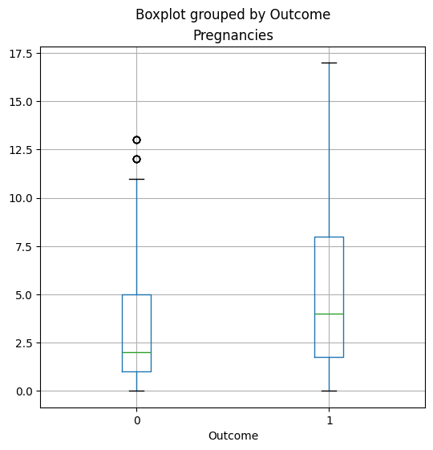

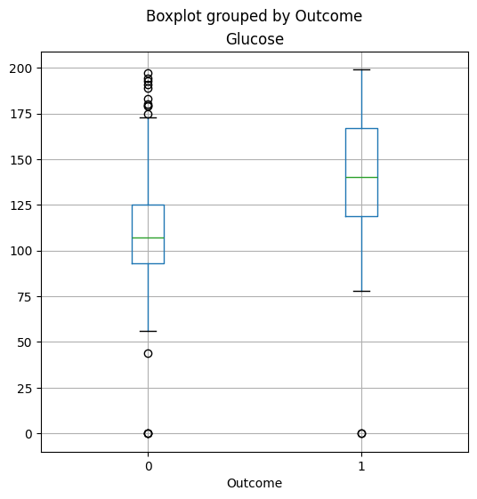

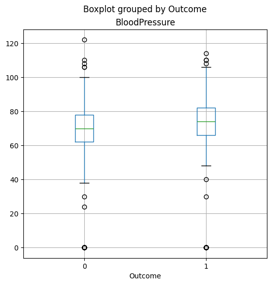

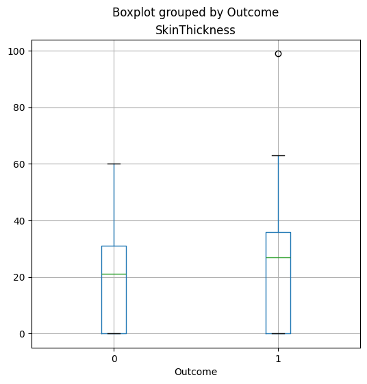

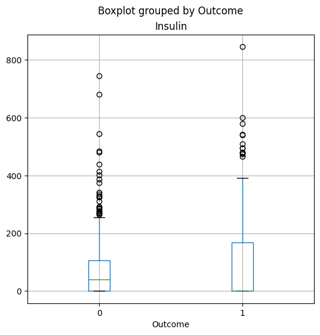

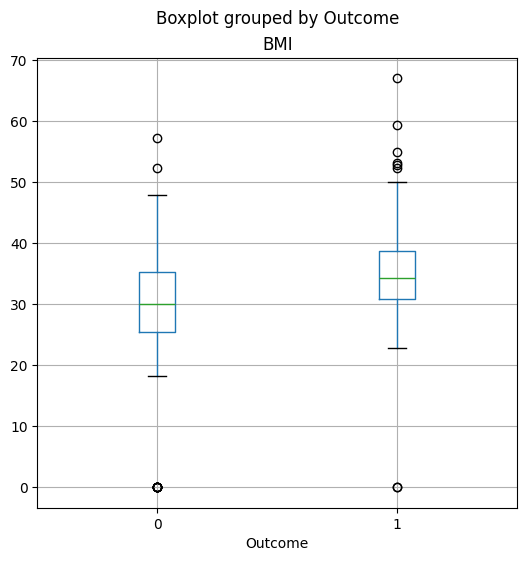

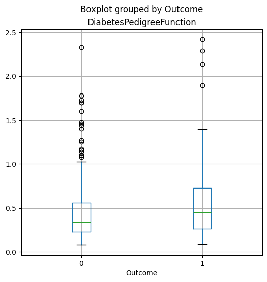

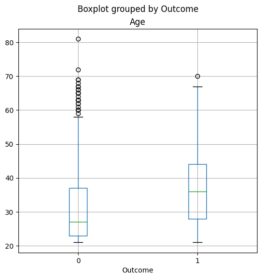

```python
from matplotlib import pyplot as plt

for col in features:
    df.boxplot(column = col, by="Outcome", figsize=(6,6))
    plt.title(col)
plt.show
```

From here, we will now split the data into testing and training portions, and begin evaluating the logistic regression model

```python
from sklearn.model_selection import train_test_split

X_train, X_test, y_train, y_test = train_test_split(X,y, test_size=0.3, random_state=0)

print(f"Training Cases = {len(X_train)}\n Testing Cases = {len(X_test)}")
```

```
Training Cases = 537
 Testing Cases = 231
```

```python
#Train and Evaluate Binary Classification Model

from sklearn.linear_model import LogisticRegression

reg = 0.01

model = LogisticRegression(C=1/reg, solver="liblinear").fit(X_train,y_train)
```

```python
predictions = model.predict(X_test)
print(f"Predicted Results {predictions}")
print(f"Actual Results {y_test}")
count = 0
for i in range(len(predictions)):
    if predictions[i] == y_test[i]:
        count += 1
print(f"Correct guesses = {count}")
print(f"Incorrect guesses = {len(predictions) - count}")
```

```
Predicted Results [1 0 0 1 0 0 1 1 0 0 1 1 0 0 0 0 1 0 0 0 1 0 0 0 0 0 0 1 0 0 0 0 0 0 0 1 0
 0 0 1 0 0 0 1 1 0 0 0 0 0 0 0 1 1 0 0 0 1 0 0 1 0 0 1 1 1 1 0 0 0 0 0 0 1
 1 0 0 1 0 0 0 0 0 0 0 0 0 0 1 0 0 0 0 0 1 0 0 1 1 0 0 0 0 0 1 0 0 0 0 1 0
 0 1 0 1 1 0 1 0 1 0 0 0 0 0 0 0 0 0 0 0 0 0 1 0 0 0 0 1 0 0 1 0 0 0 0 0 0
 0 0 0 1 0 0 1 0 1 0 0 1 1 1 0 0 1 0 0 0 0 0 0 0 0 0 1 0 0 0 0 0 0 1 0 1 0
 0 1 0 0 0 0 0 0 0 0 1 1 0 0 0 0 0 0 0 0 0 0 0 0 0 0 0 0 0 0 0 0 0 1 0 0 0
 0 1 1 1 0 0 0 0 0]
Actual Results [1 0 0 1 0 0 1 1 0 0 1 1 0 0 0 0 1 0 0 0 1 1 0 0 0 0 0 0 0 0 0 0 0 0 0 1 1
 0 0 0 0 0 0 1 1 0 0 1 1 1 0 0 1 0 0 0 0 1 1 1 1 0 0 1 1 1 1 0 0 0 0 0 0 0
 1 0 0 0 0 0 0 0 0 0 0 0 1 0 1 0 0 0 0 0 0 0 1 0 1 1 0 0 0 0 0 1 0 0 0 1 0
 1 1 1 1 1 0 0 0 1 0 0 0 0 0 0 0 1 0 0 0 0 0 1 0 1 0 1 1 0 0 0 0 0 1 0 0 0
 0 1 0 1 0 0 1 0 0 0 1 1 1 1 0 0 0 1 0 0 0 0 0 0 1 1 0 0 0 0 0 0 1 1 0 1 1
 0 1 1 1 0 0 0 0 0 0 1 1 0 0 0 0 0 0 0 1 0 0 0 1 0 1 0 0 0 0 0 1 1 0 0 1 0
 1 1 0 0 1 1 0 0 0]
Correct guesses = 180
Incorrect guesses = 51
```

Now, we will identify some metrics to see how our model performed in classification, primarily looking at the accuracy, the recall of positives, the precision of positives, and the overall f1 score

```python
from sklearn.metrics import accuracy_score, f1_score, recall_score, precision_score

print(f"Precision = {precision_score(y_test, predictions)}")
print(f"Accuracy = {accuracy_score(y_test, predictions)}")
print(f"Recall = {recall_score(y_test, predictions)}")
print(f"F1-score = {f1_score(y_test, predictions)}")
```

```
Precision = 0.7090909090909091
Accuracy = 0.7792207792207793
Recall = 0.527027027027027
F1-score = 0.6046511627906976
```

We can now see the ROC curve, which shows us the general trend of true positives and false positives and how they interact with each other. In general, we are looking to see a more bow shaped graph, as that would mean that our true postives are outpacing our false positives by a lot.

```
<function matplotlib.pyplot.show(close=None, block=None)>
```

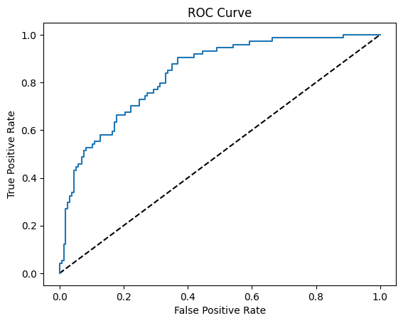

```python
from sklearn.metrics import roc_curve

y_scores = model.predict_proba(X_test)


fpr, tpr, threshold = roc_curve(y_test, y_scores[:,1])


#Plot ROC Curve
fig = plt.plot(figsize = (6,6))

#plot diagonal line
plt.plot([0,1],[0,1],'k--')
plt.plot(fpr, tpr)
plt.xlabel("False Positive Rate")
plt.ylabel("True Positive Rate")
plt.title("ROC Curve")
plt.show
```

Looking at the ROC Curve, we see that it is performing much better than average, which means that our logistic regression is fitting to the data pretty well.

For the next stage of our EDA, we will be performing some data preprocessing to see if we are able to fit the the model better to the data.

```python
#Now implementing preprocessing to see if the model gets any better
from sklearn.compose import ColumnTransformer
from sklearn.pipeline import Pipeline
from sklearn.preprocessing import StandardScaler, OneHotEncoder

#define proprocessing for numeric columns
numeric_features = [0,1,2,3,4,5,6]
numeric_transformer = Pipeline(steps = [('scalar', StandardScaler())])

categorical_features = [7]
categorical_transformer = Pipeline(steps = [('onehot', OneHotEncoder(handle_unknown='ignore'))])

preprocessor = ColumnTransformer(
    transformers = [
        ('num', numeric_transformer, numeric_features),
        ('cat', categorical_transformer, categorical_features)
    ]
)

pipeline = Pipeline(steps = [('preprocessor', preprocessor),
                             ('logregressor', LogisticRegression(C=1/reg, solver = 'liblinear'))])

model = pipeline.fit(X_train, y_train)
```

```python
#Test the model
y_pred = model.predict(X_test)

accuracy_score = accuracy_score(y_test, y_pred)
f1_score = f1_score(y_test, y_pred)
recall_score = recall_score(y_test, y_pred)
precision_score = precision_score(y_test, y_pred)

print(f"Accuracy is {accuracy_score}")
print(f"F1 is {f1_score}")
print(f"Precision is {precision_score}")
print(f"Recall is {recall_score}")
```

```
Accuracy is 0.7532467532467533
F1 is 0.5777777777777777
Precision is 0.639344262295082
Recall is 0.527027027027027
```

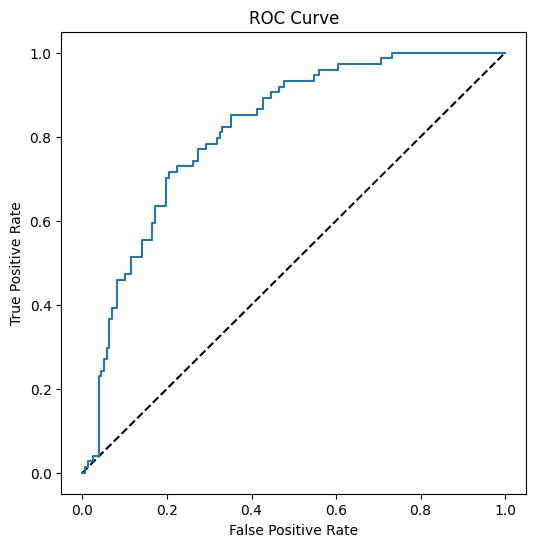

```python
#Looking at this, the model did not perform better when testing. Lets look at the model using the ROC
y_scores = model.predict_proba(X_test)

fpr, tpr, threshold = roc_curve(y_test, y_scores[:,1])
fig = plt.figure(figsize=(6,6))

plt.plot([0,1],[0,1],'k--')
plt.plot(fpr,tpr)
plt.xlabel('False Positive Rate')
plt.ylabel('True Positive Rate')

plt.title("ROC Curve")
plt.show()
```

Judging by the shape of the ROC curve, along with the varied metrics, it does not look like the data preprocessing did much to improve the fit of the model to the data. Next, we will try using ensemble methods like random forest classifer to see if we can fit the model better while also preventing overfitting.

```python
#Based on the ROC curve, this model does not do better compared, so instead lets try using a different classfier

#Lets first use a random_forest classifier
from sklearn.ensemble import RandomForestClassifier


pipeline = Pipeline(steps = [('preprocessor', preprocessor), ('logregressor', RandomForestClassifier(n_estimators = 100))])

model = pipeline.fit(X_train, y_train)
print(model)
```

```
Pipeline(steps=[('preprocessor',
                 ColumnTransformer(transformers=[('num',
                                                  Pipeline(steps=[('scalar',
                                                                   StandardScaler())]),
                                                  [0, 1, 2, 3, 4, 5, 6]),
                                                 ('cat',
                                                  Pipeline(steps=[('onehot',
                                                                   OneHotEncoder(handle_unknown='ignore'))]),
                                                  [7])])),
                ('logregressor', RandomForestClassifier())])
```

```python
#See if the model got any better
y_pred = model.predict(X_test)

accuracy = accuracy_score(y_test, y_pred)
f1 = f1_score(y_test, y_pred)
recall = recall_score(y_test, y_pred)
precision = precision_score(y_test, y_pred)

print(f"Accuracy is {accuracy}")
print(f"F1 is {f1}")
print(f"Precision is {precision}")
print(f"Recall is {recall}")
```

[output not shown]

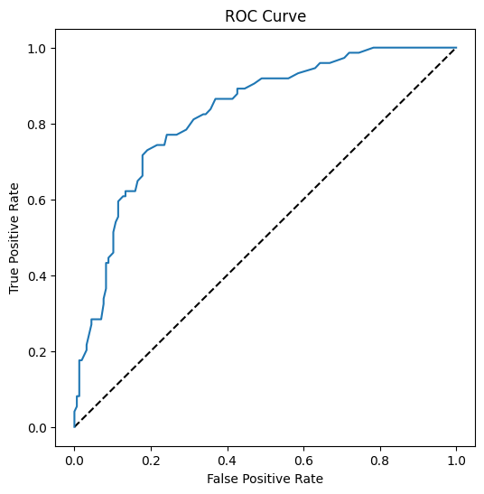

```python
y_scores = model.predict_proba(X_test)

fpr, tpr, threshold = roc_curve(y_test, y_scores[:,1])
fig = plt.figure(figsize=(6,6))

plt.plot([0,1],[0,1],'k--')
plt.plot(fpr,tpr)
plt.xlabel('False Positive Rate')
plt.ylabel('True Positive Rate')

plt.title("ROC Curve")
plt.show()
```

Comparing to the previous two models, this one does not look like it is performing much better. This probably means that although we are preventing overfitting by using the average of a bunch of models, we are not fitting any better. This probably means that there is natural variance to the graph, and a normal logistic regression classifier is able to match to the trend of the data as much as possible.